# Different Models

# Modeling

## QUADRATIC

A Quadratic model is still interpratable but not as clear as the linear.

$$Y_i = \overbrace{\underbrace{\beta_0 + \beta_1 X_i + \beta_2 X_i^2}_{E\{Y_i\}}}^\text{Quadratic Model} + \epsilon_i$$

### Examples

#### Fake

```r
set.seed(101)
  qn <- 30
  qX_i <- runif(qn, -10, 10)
  qbeta0 <- 3
  qbeta1 <- 1.8
  qbeta2 <- -3.2
  qsigma <- 26
  qepsilon_i <- rnorm(qn, 0, qsigma)
  qY_i <- qbeta0 + qbeta1*qX_i + qbeta2*(qX_i)^2  + qepsilon_i
qfabData <- data.frame(y=qY_i, x=qX_i)

qfab.lm <- lm(y ~ x + I(x^2), data=qfabData)
  pander(summary(qfab.lm))
```

|  | Estimate | Std. Error | t value | Pr(>\|t\|) |
| --- | --- | --- | --- | --- |
| **(Intercept)** | -10.11 | 6.817 | -1.483 | 0.1496 |
| **x** | 1.671 | 0.9014 | 1.854 | 0.07476 |
| **I(x^2)** | -2.938 | 0.1693 | -17.35 | 3.594e-16 |

Fitting linear model: y ~ x + I(x^2)

| Observations | Residual Std. Error | $R^2$ | Adjusted $R^2$ |
| --- | --- | --- | --- |
| 30 | 26.16 | 0.9186 | 0.9126 |

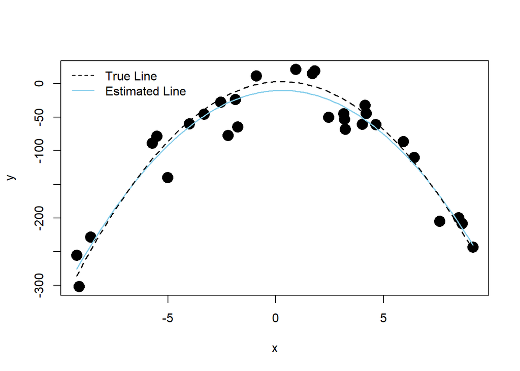

```r
  qb <- coef(qfab.lm)

plot(y ~ x, data=qfabData, pch = 16, cex = 2)
  curve(qb[1] + qb[2]*x + qb[3]*x^2, lty=1, add =T, lwd=1.5, col = "skyblue")
  curve(qbeta0 + qbeta1*x + qbeta2*x^2, add = T, lty = 2, lwd=1.5)
  legend("topleft", legend=c("True Line", "Estimated Line"), lty=c(2,1), bty="n", col = c("black","skyblue"))
```

#### Real

```r
Utilities.lm <- lm(gasbill ~ month + I((month)^2), data = Utilities)
pander(summary(Utilities.lm))
```

|  | Estimate | Std. Error | t value | Pr(>\|t\|) |
| --- | --- | --- | --- | --- |
| **(Intercept)** | 284.5 | 10.54 | 26.99 | 2.416e-51 |
| **month** | -76.62 | 3.661 | -20.93 | 7.509e-41 |
| **I((month)^2)** | 5.481 | 0.2712 | 20.21 | 1.747e-39 |

Fitting linear model: gasbill ~ month + I((month)^2)

| Observations | Residual Std. Error | $R^2$ | Adjusted $R^2$ |
| --- | --- | --- | --- |
| 117 | 30.48 | 0.7937 | 0.7901 |

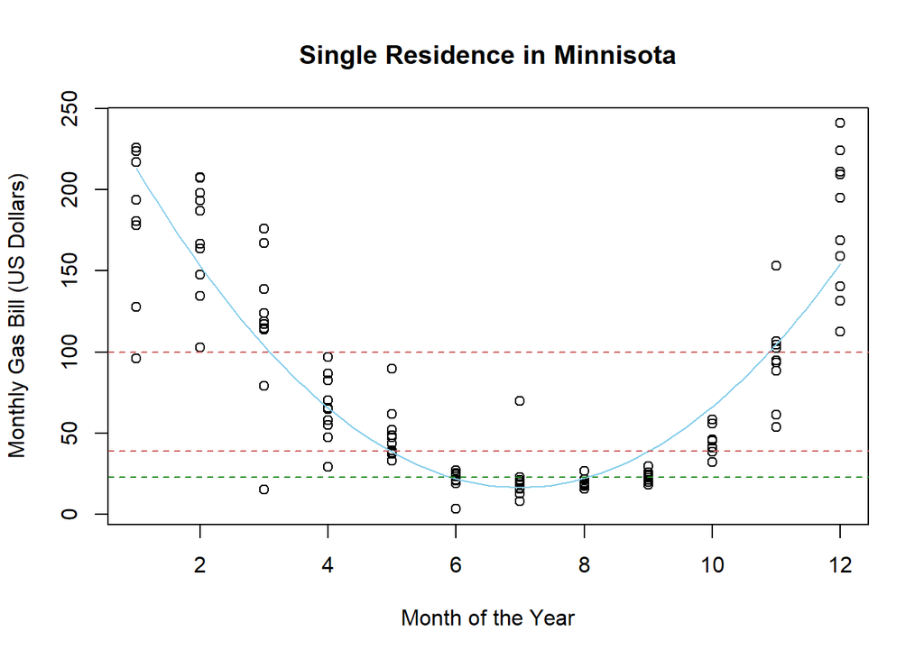

```r
plot(gasbill ~ month, data = Utilities, main = "Single Residence in Minnisota", ylab = "Monthly Gas Bill (US Dollars)", xlab = "Month of the Year")
curve(284.4558-76.6165*x+5.4807*x^2 , add = T, col = "skyblue")
abline(h = (predict(Utilities.lm, data.frame(month = 9), interval = "prediction")), col = "indianred", lty = 2)
abline(h = 22.8, lty = 2, col = "forestgreen")
```

$$Y_i = 284.4558 - 76.6165X_i + 5.4807{X_{i}}^2$$

##### diagnostics…

How well does it fit the data?

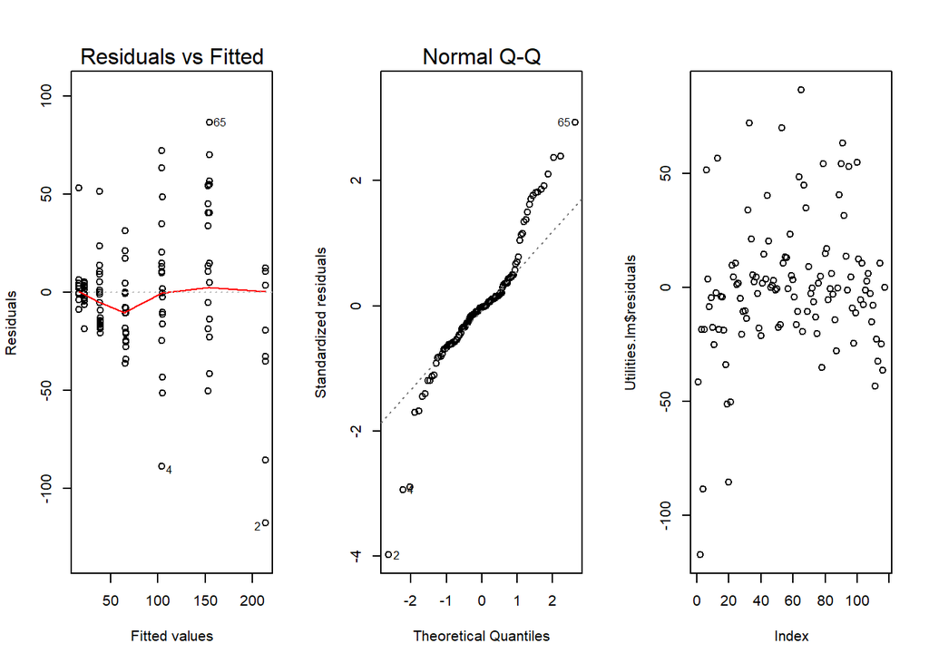

```r
par(mfrow=c(1,3))
plot(Utilities.lm, which=1:2)
plot(Utilities.lm$residuals)
```

- From the residuals vs. fitted values plot, the variance ‘does not appear’ to be constant and the model ‘could be considered to’ meet the linearity requirement. Further, points ‘2’, ‘65’, and ‘4’ are all possible outliers that should be checked for errors in encoding and possibly removed from the regression.
- From the Q-Q Plot of the residuals, normality with the points going out of the “normality boundary lines” at the “norm quantiles” of -1 on the left and 1 on the right of the graph.
- From the Residuals vs Order plot we see a possible pattern. Using View(Utilities) we see that the data is sorted by the ‘year’ column (enter the name of the column the Utilities data is sorted by). It is reasonable to assume that the error terms ‘are not’ independent because of some consistent, though modest changes over time in the data.

##### predicting…

```r
pander(predict(Utilities.lm, data.frame(month = 9), interval = "prediction"))
```

| fit | lwr | upr |
| --- | --- | --- |
| 38.85 | -22 | 99.7 |

What range of possible gas bill amounts do you predict for the September bill? How confident are you in your prediction?

- At 95% confidence, our model shows that September’s possible gas bill amounts range from ‘0’ (because bill’s can’t be negative) to ‘99.69641’, with a predicted value of ‘38.84658’ dollars.

Compute the mean of just September’s gas bills and draw a horizontal reference line for this mean on your scatterplot. How does this mean compare to the prediction?

- The mean gas bill for just September is ‘22.8’.
- This is ‘16.04658’ dollars less than the prediction from our regression model.

So which one is right? Good question. While we haven’t seen a lot of variability in past September bills for this data set, we do see high variability in many of the other months. It isn’t unreasonable to assume that September could be prone to this same variability. The regression accounts for the variability of all months. Using just September isolates the data to just September’s history, providing a more narrow view of the data. However, this particular regression model doesn’t seem to perform very well on months 1, 9 and 10 (January, September and October) when it comes to capturing the average of those months. So… hard to say. But more work is needed to really capture the essence of this data.

## TWO LINES

A two lines model is great. It models it is very interpretable.

$$Y_i = \overbrace{\underbrace{\beta_0 + \beta_1 X_{1i} + \beta_2 X_{2i} + \beta_3 X_{1i} X_{2i}}_{E\{Y_i\}}}^\text{Two-lines Model} + \epsilon_i$$

### Examples

#### Fake

```r
set.seed(200)
  n.tl <- 40
  X_1i <- runif(n.tl, 15, 45)
  X_2i <- sample(c(0,1), n.tl, replace = T)
  beta0.tl <- 2
  beta1.tl <- 3
  beta2.tl <- 1
  beta3.tl <- 5
  sigma.tl <- 10
  epsilon_i.tl <- rnorm(n.tl, 0, sigma.tl)
  Y_i.tl <- beta0.tl + beta1.tl*X_1i +  beta2.tl*X_2i + beta3.tl*X_1i*X_2i + epsilon_i.tl
fabData.tl <- data.frame(y=Y_i.tl, x1=X_1i, x2=X_2i)

fab.lm.tl <- lm(y ~ x1 + x2 + x1:x2, data=fabData.tl)
  b.tl <- fab.lm.tl$coefficients
  pander(summary(fab.lm.tl) )
```

|  | Estimate | Std. Error | t value | Pr(>\|t\|) |
| --- | --- | --- | --- | --- |
| **(Intercept)** | 14.93 | 8.78 | 1.701 | 0.09759 |
| **x1** | 2.638 | 0.2871 | 9.188 | 5.673e-11 |
| **x2** | -9.488 | 11.91 | -0.7969 | 0.4307 |
| **x1:x2** | 5.35 | 0.3927 | 13.62 | 8.93e-16 |

Fitting linear model: y ~ x1 + x2 + x1:x2

| Observations | Residual Std. Error | $R^2$ | Adjusted $R^2$ |
| --- | --- | --- | --- |
| 40 | 9.316 | 0.9894 | 0.9885 |

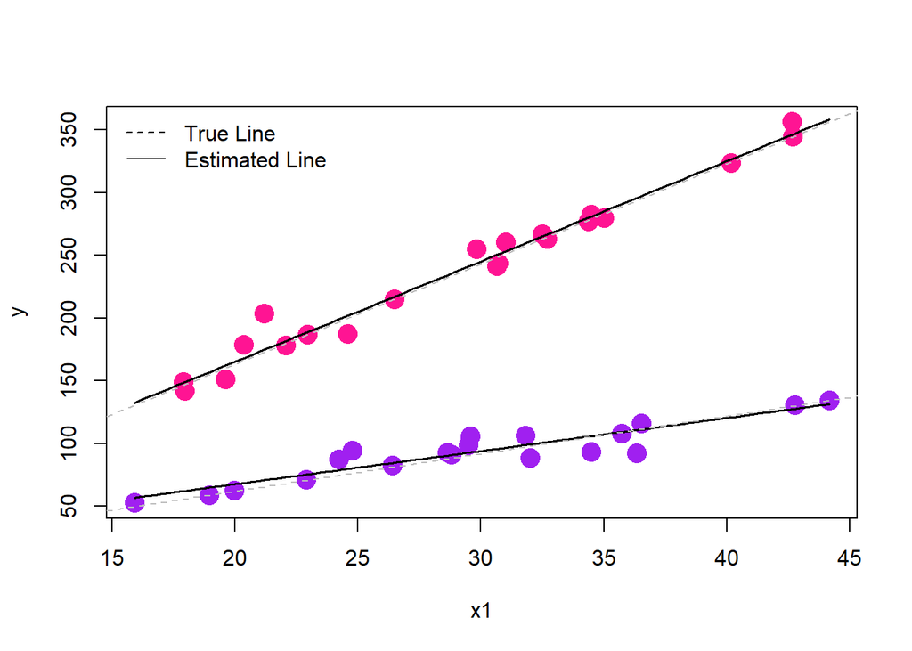

```r
  palette(c("purple","deeppink"))
plot(y ~ x1, col = factor(x2), data=fabData.tl, pch = 16, cex = 2)
  curve(b.tl[1] + b.tl[2]*x, add = T, lwd = 1.5)
  curve((b.tl[1]+b.tl[3]) + (b.tl[2]+b.tl[4])*x, add = T, lwd = 1.5)
  abline(beta0.tl, beta1.tl, lty=2, col = "gray")
  abline(beta0.tl+beta2.tl, beta1.tl+beta3.tl, lty=2, col = "gray")
  legend("topleft", legend=c("True Line", "Estimated Line"), lty=c(2,1), bty="n")
```

#### Real

```r
mttllm <- lm(mpg ~ qsec + am + qsec:am, data = mtcars)
pander(summary(mttllm))
```

|  | Estimate | Std. Error | t value | Pr(>\|t\|) |
| --- | --- | --- | --- | --- |
| **(Intercept)** | -9.01 | 8.218 | -1.096 | 0.2823 |
| **qsec** | 1.439 | 0.45 | 3.197 | 0.003432 |
| **am** | -14.51 | 12.48 | -1.163 | 0.2548 |
| **qsec:am** | 1.321 | 0.7017 | 1.883 | 0.07012 |

Fitting linear model: mpg ~ qsec + am + qsec:am

| Observations | Residual Std. Error | $R^2$ | Adjusted $R^2$ |
| --- | --- | --- | --- |
| 32 | 3.343 | 0.722 | 0.6923 |

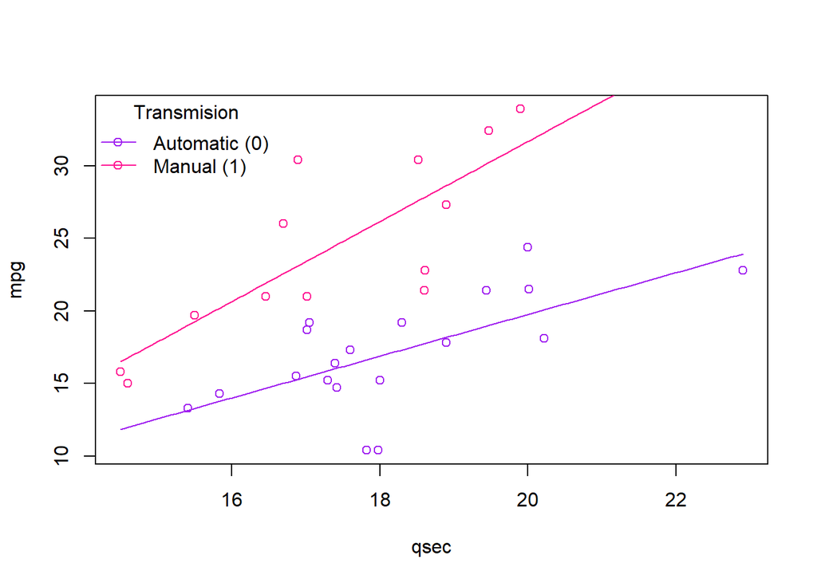

```r
palette(c("purple","deeppink"))
plot(mpg ~ qsec, col = as.factor(am), data = mtcars)
curve(-9.0099 + 1.4385*x, add = TRUE, col = "purple")
curve((-9.0099-14.5107) + (1.4385+1.3214)*x, add = TRUE, col = "deeppink")
legend("topleft", legend=c("Automatic (0)", "Manual (1)"), title = "Transmision", lty = 1, pch = 1, bty="n", col = c("purple","deeppink"))
```

$$\hat{Y-i} = -9.01 + 1.439*X_{1i} - 14.51X_{2i} + 1.321X_{1i}X_{2i}$$

Thus, the null hypotheses for this test of the interaction term being meaningful would be written as
$$H_0: \beta_3 = 0$$
and the alternative would be that it does not equal zero. That is because, if this term were zero, then the interaction of qsec and am does not add anything meaningful to the model.

The p-value of this hypothesis test is: ‘0.07012’

##### diagnosing…

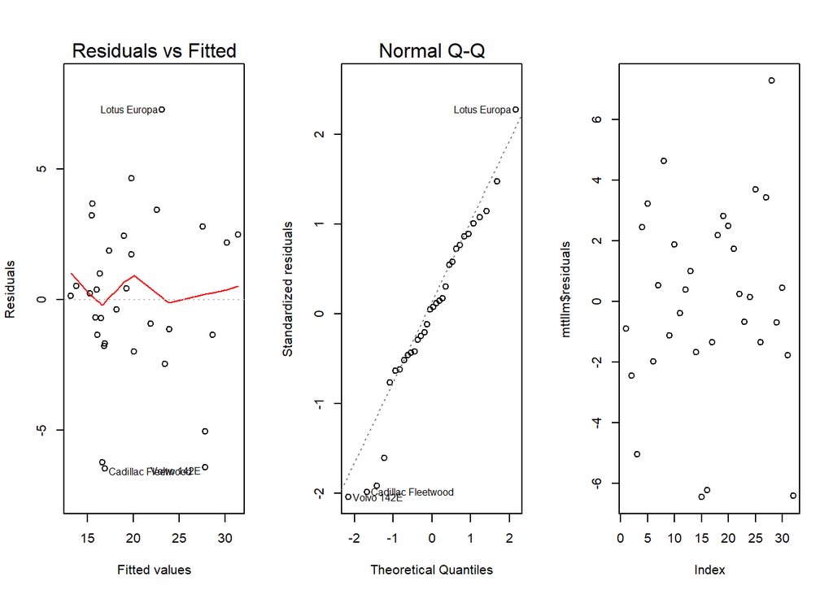

```r
par(mfrow=c(1,3))
plot(mttllm, which=1:2)
plot(mttllm$residuals)
```

## CUBIC

A cubic function is very rarely seen in the real world and has little to no interpretability, so I will only model a fake situation.

$$Y_i = \overbrace{\underbrace{\beta_0 + \beta_1 X_i + \beta_2 X_i^2 + \beta_3 X_i^3}_{E\{Y_i\}}}^\text{Cubic Model} + \epsilon_i$$

```r
set.seed(82)
  cn <- 33
  cX_i <- runif(n.tl, -1, 1)
  cbeta0 <- 428
  cbeta1 <- 40
  cbeta2 <- 80
  cbeta3 <- 214
  csigma <- 20
  cepsilon_i <- rnorm(cn, 0, csigma)
  cY_i <- cbeta0 + cbeta1*cX_i +  cbeta2*(cX_i)^2 + cbeta3*(cX_i)^3 + cepsilon_i
cfabData <- data.frame(y=cY_i, x=cX_i)

cfab.lm <- lm(y ~ x + I(x^2) + I(x^3), data=cfabData)
  cb <- cfab.lm$coefficients
  pander(summary(cfab.lm) )
```

|  | Estimate | Std. Error | t value | Pr(>\|t\|) |
| --- | --- | --- | --- | --- |
| **(Intercept)** | 430.1 | 5.154 | 83.46 | 8.36e-43 |
| **x** | 20.76 | 14.53 | 1.429 | 0.1616 |
| **I(x^2)** | 76.38 | 13.13 | 5.816 | 1.223e-06 |
| **I(x^3)** | 245.8 | 23.09 | 10.64 | 1.147e-12 |

Fitting linear model: y ~ x + I(x^2) + I(x^3)

| Observations | Residual Std. Error | $R^2$ | Adjusted $R^2$ |
| --- | --- | --- | --- |
| 40 | 22.06 | 0.9459 | 0.9414 |

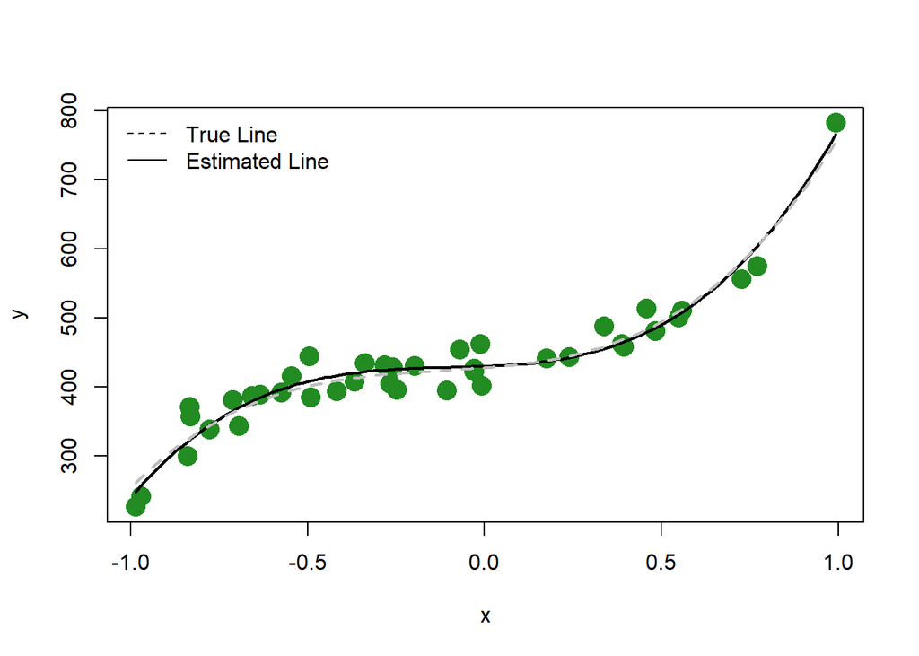

```r
plot(y ~ x, data=cfabData, pch=16, cex=2, col="forestgreen")
  curve(cb[1] + cb[2]*x + cb[3]*x^2 + cb[4]*x^3, add=T, lwd=2)
  curve(cbeta0 + cbeta1*x + cbeta2*x^2 + cbeta3*x^3, lwd=2,  lty=2, col="gray", add=T)
  legend("topleft", legend=c("True Line", "Estimated Line"), lty=c(2,1), bty="n")
```

## TWO QUADRATIC

For fun, lets look at a model that combines quadratic and the two lines models…

$$Y_i = \beta_0 + \beta_1X_{1i} + \beta_2 X_{1i}^2 + \beta_3X_{2i} + \beta_4 X_{1i}X_{2i} + \beta_5 X_{1i}^2X_{2i} + \epsilon_i \space \text{where} \epsilon_i \sim N(0, \sigma^2)$$

```r
meh.lm <- lm(qsec ~ disp + I(disp^2) + am + disp:am + I(disp^2):am, data = mtcars)
pander(summary(meh.lm))
```

|  | Estimate | Std. Error | t value | Pr(>\|t\|) |
| --- | --- | --- | --- | --- |
| **(Intercept)** | 26.19 | 1.728 | 15.16 | 2.024e-14 |
| **disp** | -0.04937 | 0.0127 | -3.888 | 0.0006256 |
| **I(disp^2)** | 6.607e-05 | 2.133e-05 | 3.097 | 0.004646 |
| **am** | -3.663 | 2.343 | -1.563 | 0.1301 |
| **disp:am** | -0.002926 | 0.02335 | -0.1253 | 0.9012 |
| **I(disp^2):am** | 1.866e-05 | 5.143e-05 | 0.3628 | 0.7197 |

Fitting linear model: qsec ~ disp + I(disp^2) + am + disp:am + I(disp^2):am

| Observations | Residual Std. Error | $R^2$ | Adjusted $R^2$ |
| --- | --- | --- | --- |
| 32 | 1.033 | 0.7197 | 0.6658 |

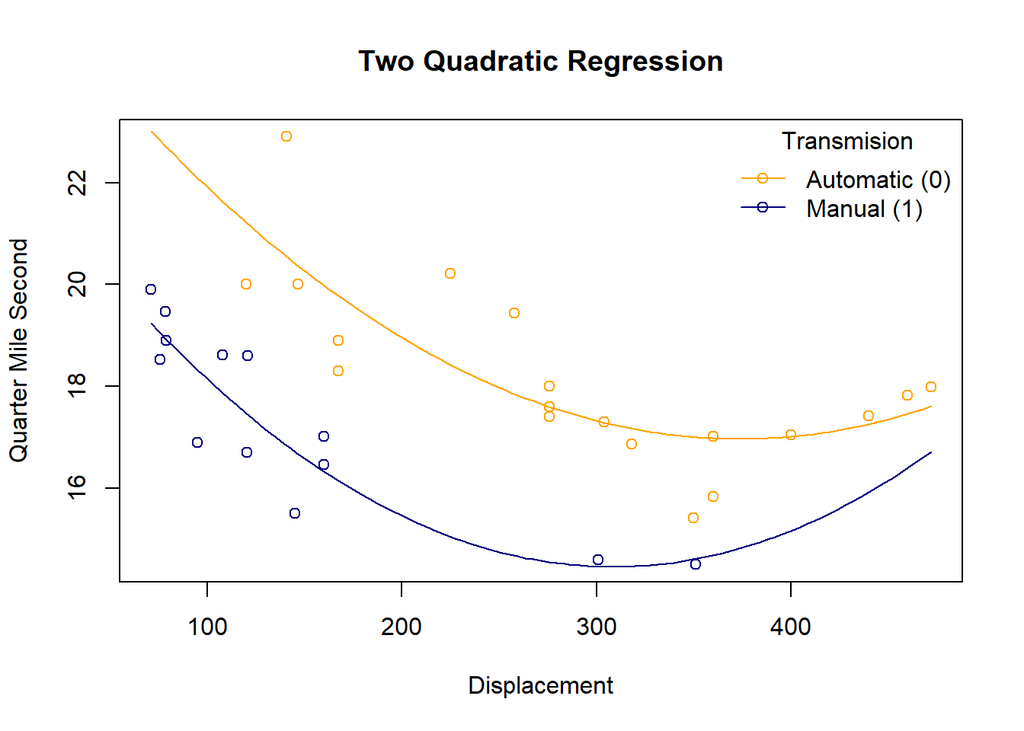

```r
palette(c("orange","navy"))
plot(qsec ~ disp, col = as.factor(am), data = mtcars, main = "Two Quadratic Regression", ylab = "Quarter Mile Second", xlab = "Displacement", sub = "")
curve((2.619e+01)+(-4.937e-02)*x + (6.607e-05)*x^2, add=TRUE, col = "orange")
curve((2.619e+01-3.663e+00)+(-4.937e-02-2.926e-03)*x + (6.607e-05+1.866e-05)*x^2, add=TRUE, col = "navy")
legend("topright", legend=c("Automatic (0)", "Manual (1)"), title = "Transmision", lty = 1, pch = 1, bty="n", col = c("orange","navy"))
```

$$\underbrace{\hat{Y}_i}_\text{qsec} = 26.19 -0.04937 \underbrace{X_{1i}}_\text{disp} + 0.00006607 X_{1i}^2 - 3.663 \underbrace{X_{2i}}_\text{am == 1} - 0.002926 X_{1i}X_{2i} + 0.00001866 X_{1i}^2X_{2i}$$

Using the summary above, perform the appropriate t-tests to determine which interaction terms are needed in this regression model.

These show that ‘either’ could be dropped from the model.

##### diaganosing…

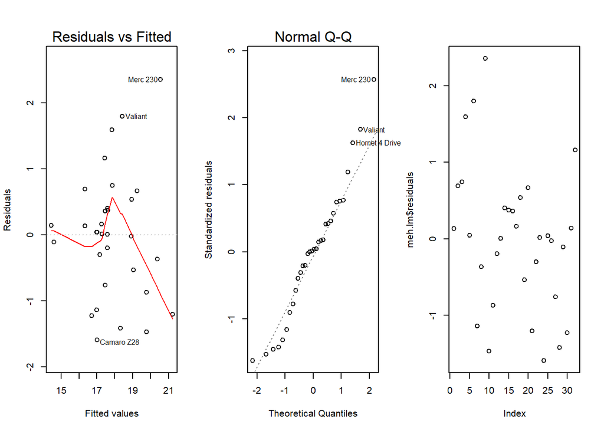

```r
par(mfrow = c(1,3))
plot(meh.lm, which = 1:2)
plot(meh.lm$residuals)
```

The plots are difficult to read, but don’t show strong enough evidence to discredit the regression results.

##### drop?…

Drop the “least significant” term from the model. This is a silly statement really, but is an accepted practice when searching for a “best” model in regression analysis. What has changed?

```r
meh.lm2 <- lm(qsec ~ disp + I(disp^2) + am + I(disp^2):am, data = mtcars)
pander(summary(meh.lm2))
```

|  | Estimate | Std. Error | t value | Pr(>\|t\|) |
| --- | --- | --- | --- | --- |
| **(Intercept)** | 26.3 | 1.442 | 18.25 | 1.03e-16 |
| **disp** | -0.05024 | 0.01046 | -4.803 | 5.175e-05 |
| **I(disp^2)** | 6.75e-05 | 1.768e-05 | 3.817 | 0.000717 |
| **am** | -3.939 | 0.784 | -5.024 | 2.858e-05 |
| **I(disp^2):am** | 1.238e-05 | 1.143e-05 | 1.083 | 0.2885 |

Fitting linear model: qsec ~ disp + I(disp^2) + am + I(disp^2):am

| Observations | Residual Std. Error | $R^2$ | Adjusted $R^2$ |
| --- | --- | --- | --- |
| 32 | 1.014 | 0.7196 | 0.678 |

Interestingly, the p-value for the “am” term, $\beta_3$ in the original model, is now significant. The p-value for this term is now ‘2.86e-05’, whereas it was previously ‘0.130076’. This shows why we should only drop one term at a time from a regression, rather than dropping all significant terms. Everything can change with the addition or deletion of just a single term.